# Example analyses with VertexWiseR - Example 3

Charly H. A. Billaud

2026-10-19

This article introduces vertex-wise statistical modelling of subcortical surfaces available since update v1.5.0. The subcortical surfaces it is currently compatible with are either derived from FSL FIRST (Patenaude et al. 2011) or FreeSurfer “ASeg” (Fischl 2012) subcortical volumetric segmentations, as well as ASeg-based CIFTI subcortical grayordinates (Glasser et al. 2013). The volumes are converted to 3D meshes and surface-based metrics (thickness, surface area, curvature) produced using the python module SubCortexMesh. VertexWiseR can extract the surface measures obtained with the latter package.

## Requirements

Analysis and manipulation of the subcortical surfaces require additional utility data to be downloaded and stored in the R package’s external data (`system.file('extdata',package='VertexWiseR')`). A prompt will automatically be triggered to assist downloading it whenever subcortical surfaces are inputted (users can trigger it themselves by typing `VertexWiseR:::scm_database_check(template='fsaverage')`). The size depends on the template used (~19.9 MB for FreeSurfer ‘fsaverage’, ~17.3 MB for FSL ‘fslfirst’).

## Extracting ASeg subcortical surfaces

SubCortexMesh’s surface metric output in template space can be extracted by VertexWiseR as in the other [surface extraction functions](https://cogbrainhealthlab.github.io/VertexWiseR/articles/VertexWiseR_surface_extraction.html), generating compact (bilateral) matrices for all applicable subcortical surfaces. Here is an example of code which was run to obtain the demo data:

```r
for (metric in c('thickness','curvature'))
{
  subcortical_m=SCMvextract(sdirpath = 'surface_metrics/',
                            outputdir = "aseg_matrices/",
                            measure = metric,
                            roilabel = c('thalamus','caudate'),
                            template='fsaverage',
                            subj_ID = TRUE)
}
```

⚠️ Note that if the SubCortexMesh output contains merged surface objects such as “allaseg” or “allfslfirst”, they will also be extracted along with the individual regions, unless it is specified in the `roilabel` argument (e.g., if `roilabel="allaseg"`, only the merged subcortices will be extracted).

## Example analysis on the thalamus and caudate nuclei

The analysis will use surface data already extracted in R from a preprocessed subjects directory, which we make available so you do not need to preprocess a sample yourself. To obtain it, we had thickness and curvature metrics data from a SubCortexMesh output directory based on FreeSurfer segmentations of the SUDMEX_CONN dataset (Garza-Villarreal et al. 2017).

The demo data (~216 MB) can be downloaded from the package’s github repository with the following function:

```r
#This will save the demo_data directory in a temporary directory (tempdir(), but you can change it to your own path)
demodata=VertexWiseR:::dl_demo(path=tempdir(), quiet=TRUE)
```

As in the SCMvextract() code above, metrics from the bilateral thalami and caudate nuclei were extracted. The surface data can be loaded that way:

```r
thalamus_thickness = readRDS(file=paste0(demodata,"/SUDMEX_CONN_thalamus_thickness.rds"))
thalamus_curvature = readRDS(file=paste0(demodata,"/SUDMEX_CONN_thalamus_curvature.rds"))

caudate_thickness = readRDS(file=paste0(demodata,"/SUDMEX_CONN_caudate_thickness.rds"))
caudate_curvature = readRDS(file=paste0(demodata,"/SUDMEX_CONN_caudate_curvature.rds"))
```

To load the corresponding behavioural data (all subjects indiscriminately):

```r
beh_data = readRDS(paste0(demodata,"/SUDMEX_CONN_behdata.rds"))
```

Here, we are interested in the effect of group (cocaine use disorder (CUD) versus control) on the thalami and caudate nuclei (replicating a similar analysis that was done by (Xu et al. 2023)). We can run a vertex-wise analysis model with random field theory-based cluster correction, testing for the effect of group on each region and each metric:

```r
for (surf_data in c('thalamus_thickness', 'thalamus_curvature',
                    'caudate_thickness', 'caudate_curvature'))
{
model=RFT_vertex_analysis(model = as.factor(beh_data$group),
                          contrast = as.factor(beh_data$group),
                          surf_data = get(surf_data))
assign(paste0('model_',surf_data),model)
}
```

```r
model_thalamus_thickness$cluster_level_results
```

```
## $`Positive contrast`
## [1] "No significant clusters"
##
## $`Negative contrast`
##   clusid nverts      P     X     Y     Z tstat         region
## 1      1    213 <0.001 106.1 132.1 163.4 -3.05 Right Thalamus
## 2      2    186 <0.001 153.8 128.7 163.5 -3.62  Left Thalamus
## 3      3    162  0.001 132.3 133.0 148.4 -3.55  Left Thalamus
## 4      4    127  0.002 115.3 118.5 161.0 -3.35 Right Thalamus
## 5      5    171  0.002 136.0 112.5 141.9 -3.20  Left Thalamus
```

```r
model_thalamus_curvature$cluster_level_results
```

```
## $`Positive contrast`
##   clusid nverts      P     X     Y     Z tstat        region
## 1      1    119 <0.001 139.1 113.9 135.3  3.45 Left Thalamus
## 2      2     62  0.005 134.0 130.5 154.0  4.13 Left Thalamus
## 3      3     45  0.014 153.0 133.0 157.5  3.60 Left Thalamus
##
## $`Negative contrast`
##   clusid nverts      P     X     Y     Z tstat         region
## 1      1    119 <0.001 143.5 116.7 133.0 -3.57  Left Thalamus
## 2      2     72  0.024 122.5 116.9 154.3 -4.19 Right Thalamus
## 3      3     63  0.025 135.0 126.6 159.2 -3.42  Left Thalamus
## 4      4     85  0.031 128.0 122.5 142.7 -3.96 Right Thalamus
```

```r
model_caudate_thickness$cluster_level_results
```

```
## $`Positive contrast`
## [1] "No significant clusters"
##
## $`Negative contrast`
##   clusid nverts      P     X     Y     Z tstat        region
## 1      1     77 <0.001 112.9 133.0 116.7 -3.44 Right Caudate
## 2      2     74  0.004 107.3 120.9 116.1 -2.93 Right Caudate
## 3      3     74  0.046 119.5 128.7 110.0 -3.61 Right Caudate
```

```r
model_caudate_curvature$cluster_level_results
```

```
## $`Positive contrast`
## [1] "No significant clusters"
##
## $`Negative contrast`
##   clusid nverts    P     X     Y     Z tstat        region
## 1      1     72 0.01 121.3 132.2 116.7 -3.63 Right Caudate
```

Since [SubCortexMesh v.1.1.0](https://subcortexmesh.readthedocs.io/en/latest/atlases.html), anatomical sub-parcellations are also available for surfaces in fsaverage space, and give more specific location in regions’ nuclei or subfields. VertexWiseR can use them with the argument ‘atlas=2’ (the caudate nuclei do not have subparcellations, so we show it for the thalami):

```r
for (surf_data in c('thalamus_thickness', 'thalamus_curvature'))
{
model=RFT_vertex_analysis(model = as.factor(beh_data$group),
                          contrast = as.factor(beh_data$group),
                          surf_data = get(surf_data),
                          atlas=2) #anatomical atlas, applicable for fsaverage SCM data
assign(paste0('model_',surf_data),model)
}
```

```r
model_thalamus_thickness$cluster_level_results
```

```
## $`Positive contrast`
## [1] "No significant clusters"
##
## $`Negative contrast`
##   clusid nverts      P     X     Y     Z tstat
## 1      1    213 <0.001 106.1 132.1 163.4 -3.05
## 2      2    186 <0.001 153.8 128.7 163.5 -3.62
## 3      3    162  0.001 132.3 133.0 148.4 -3.55
## 4      4    127  0.002 115.3 118.5 161.0 -3.35
## 5      5    171  0.002 136.0 112.5 141.9 -3.20
##                                      region
## 1              Thalamus_Pulvinar-Inferior_R
## 2                Thalamus_Pulvinar-Medial_L
## 3    Thalamus_Centromedian-Parafascicular_L
## 4                Thalamus_Pulvinar-Medial_R
## 5 Thalamus_Laterodorsal-Lateral-Posterior_L
```

```r
model_thalamus_curvature$cluster_level_results
```

```
## $`Positive contrast`
##   clusid nverts      P     X     Y     Z tstat
## 1      1    119 <0.001 139.1 113.9 135.3  3.45
## 2      2     62  0.005 134.0 130.5 154.0  4.13
## 3      3     45  0.014 153.0 133.0 157.5  3.60
##                                   region
## 1             Thalamus_Ventral-Lateral_L
## 2 Thalamus_Centromedian-Parafascicular_L
## 3           Thalamus_Pulvinar-Inferior_L
##
## $`Negative contrast`
##   clusid nverts      P     X     Y     Z tstat                        region
## 1      1    119 <0.001 143.5 116.7 133.0 -3.57    Thalamus_Ventral-Lateral_L
## 2      2     72  0.024 122.5 116.9 154.3 -4.19    Thalamus_Pulvinar-Medial_R
## 3      3     63  0.025 135.0 126.6 159.2 -3.42    Thalamus_Pulvinar-Medial_L
## 4      4     85  0.031 128.0 122.5 142.7 -3.96 Thalamus_Mediodorsal-Medial_R
```

We can plot the model results together in one summary plot by binding the maps:

```r
thalamusmaps=rbind(model_thalamus_thickness$thresholded_tstat_map,
                  model_thalamus_curvature$thresholded_tstat_map)

caudatemaps= rbind(model_caudate_thickness$thresholded_tstat_map,
              model_caudate_curvature$thresholded_tstat_map)
```

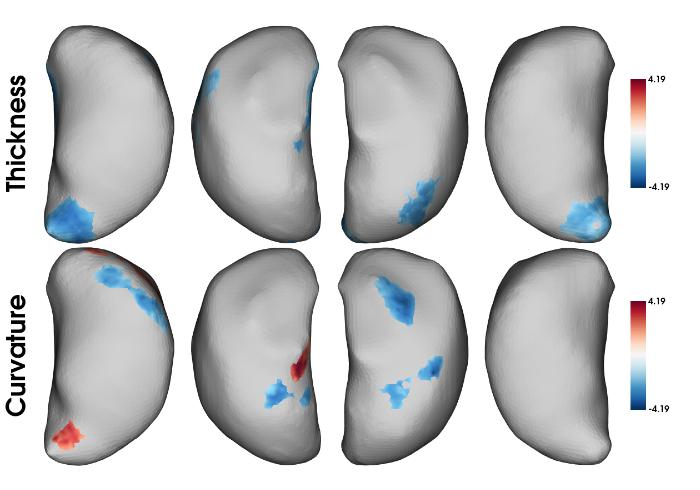

```r
thalamusplot=plot_surf(thalamusmaps,
          filename='SUDMEX_CONN_thalamus_tstatmaps.png',
          title=c('Thickness','Curvature'),
          smooth_mesh=20,
          show.plot.window=TRUE)
```

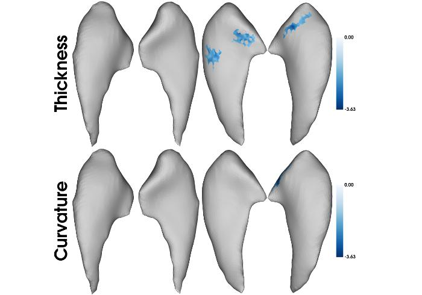

```r
caudateplot=plot_surf(caudatemaps,
          filename='SUDMEX_CONN_caudate_tstatmaps.png',
          title=c('Thickness','Curvature'),
          smooth_mesh=20,
          show.plot.window=TRUE)
```

The outcome shows that compared to controls, CUD patients had decreases in thickness of the bilateral thalami, and various shapes alterations in curvature.

Note regarding anatomical orientations: for the amygdala, brain-stem and cerebellar plots, the upper part of the image is the superior part of the brain and lower the inferior. While for the rest, more horizontal structures, upper means anterior and lower means posterior, where the second and third panels are medial views (looking from the center toward the side/exterior of the brain) and vice versa for the first and fourth panel. You may use plot_surf3d() to get a more explicit orientation.

## Analysing all subcortices together

SubCortexMesh has a function to merge all subcortices, assuming all of them are available, into one single object for each metric. For example, the “allaseg” can be outputted in SubCortexMesh’s surface_metrics/ directory, and extracted via SCMvextract():

```r
allaseg_thickness_data = SCMvextract(sdirpath = 'surface_metrics/',
                                     outputdir = "sudmex_conn_surf_data_scm/",
                                     measure = 'thickness',
                                     roilabel = 'allaseg',
                                     template='fsaverage',

                                     subj_ID = TRUE)
```

As an example, we provide the “allaseg” thickness for the same dataset and run the same analysis:

```r
allaseg_thickness = readRDS(file=paste0(demodata,"/SUDMEX_CONN_allaseg_thickness.rds"))
allaseg_model=RFT_vertex_analysis(
  model = as.factor(beh_data$group),
  contrast = as.factor(beh_data$group),
  surf_data = allaseg_thickness)
```

```r
allaseg_model$cluster_level_results
```

```
## $`Positive contrast`
##   clusid nverts      P     X     Y     Z tstat                  region
## 1      1    363 <0.001 121.1 137.6 125.2  3.62         right-ventraldc
## 2      2    157 <0.001 144.8 136.5 137.8  3.31          left-ventraldc
## 3      3    312  0.002 113.0 135.4 155.4  2.76              brain-stem
## 4      4    176  0.005 147.9 131.4 158.3  3.14          left-ventraldc
## 5      5    111  0.006  92.6 137.9 136.2  2.89           right-putamen
## 6      6    160  0.008 107.3 131.5 159.0  3.18         right-ventraldc
## 7      7   1344  0.015 150.0 179.1 167.6  2.91  left-cerebellum-cortex
## 8      8     65  0.015 100.6 133.1 136.3  3.10           right-putamen
## 9      9    620  0.028  99.8 170.5 167.9  2.94 right-cerebellum-cortex
##
## $`Negative contrast`
##    clusid nverts      P     X     Y     Z tstat                  region
## 1       1   2062 <0.001 128.2 134.8 177.7 -3.22  left-cerebellum-cortex
## 2       2    223 <0.001 125.7 135.9 136.1 -4.36         right-ventraldc
## 3       3   1757 <0.001 104.5 148.0 171.7 -3.10 right-cerebellum-cortex
## 4       4    213 <0.001 106.1 132.1 163.4 -3.05          right-thalamus
## 5       5    186  0.001 153.8 128.7 163.5 -3.62           left-thalamus
## 6       6     77  0.001 112.9 133.0 116.7 -3.44           right-caudate
## 7       7     99  0.005 151.4 134.2 150.0 -3.44          left-ventraldc
## 8       8    162  0.007 132.3 133.0 148.4 -3.55           left-thalamus
## 9       9    120  0.008 150.5 160.0 186.3 -3.58  left-cerebellum-cortex
## 10     10   1605  0.014 171.1 174.7 204.5 -4.07  left-cerebellum-cortex
## 11     11     92  0.014 100.9 136.2 145.3 -3.73         right-ventraldc
## 12     12    127  0.016 115.3 118.5 161.0 -3.35          right-thalamus
## 13     13    171  0.022 136.0 112.5 141.9 -3.20           left-thalamus
## 14     14     74  0.029 107.3 120.9 116.1 -2.93           right-caudate
## 15     15     96  0.031 106.3 147.3 151.8 -3.38       right-hippocampus
## 16     16     68  0.035 106.2 134.8 141.4 -3.26         right-ventraldc
```

We can plot the subcortices together the same way:

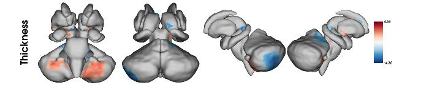

```r
allasegplot=plot_surf(
  surf_data=allaseg_model$thresholded_tstat_map,
  filename='SUDMEX_CONN_allaseg_tstatmaps.png',
  title='Thickness',
  smooth_mesh=20,
  show.plot.window=TRUE)
```

Since some regions may be harder to see in the 2d plot, plot_surf3d() function has a special interactive slider for the “all merged” surface in the GUI that allows spacing out each regions from each other (this only applies to the merged surfaces):

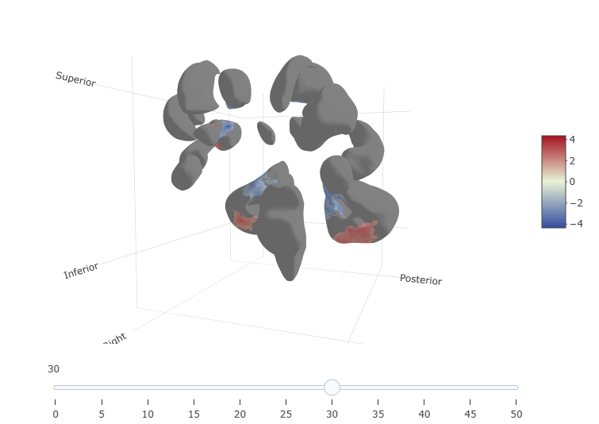

```r
plot_surf3d(surf_data = allaseg_model$thresholded_tstat_map,
            surf_color = 'grey', smooth_mesh = 50)
```

(This is just a screenshot)

Although SubCortexMesh requires that all regions be processed for the encompassing surface to be created, it is possible to omit specific regions from the analysis by turning to NA their corresponding vertices.

Users can identify the exact vertex indices in the python module’s template_data. Here is the table that applies for ASeg:

| id | label | n_vert | n_vert_cumul |
| --- | --- | --- | --- |
| 0 | brain-stem | 9452 | 9452 |
| 1 | left-accumbens-area | 1022 | 10474 |
| 2 | left-amygdala | 1638 | 12112 |
| 3 | left-caudate | 3440 | 15552 |
| 4 | left-cerebellum-cortex | 19550 | 35102 |
| 5 | left-hippocampus | 4046 | 39148 |
| 6 | left-pallidum | 1600 | 40748 |
| 7 | left-putamen | 4268 | 45016 |
| 8 | left-thalamus | 3936 | 48952 |
| 9 | left-ventraldc | 3550 | 52502 |
| 10 | right-accumbens-area | 1022 | 53524 |
| 11 | right-amygdala | 1792 | 55316 |
| 12 | right-caudate | 3500 | 58816 |
| 13 | right-cerebellum-cortex | 19664 | 78480 |
| 14 | right-hippocampus | 4086 | 82566 |
| 15 | right-pallidum | 1600 | 84166 |
| 16 | right-putamen | 4126 | 88292 |
| 17 | right-thalamus | 3832 | 92124 |
| 18 | right-ventraldc | 3594 | 95718 |

So, for example, if one does not want to count the cerebella in the analysis, they can follow the cumulative vertex count and set them to NA, like that:

```r
allaseg_thickness$surf_obj[,c((15552+1):35102,(58816+1):78480)]=NA

allaseg_model_nocerebellum=RFT_vertex_analysis(
  model = as.factor(beh_data$group),
  contrast = as.factor(beh_data$group),
  surf_data = allaseg_thickness)
```

```r
allaseg_model_nocerebellum$cluster_level_results
```

```
## $`Positive contrast`
##   clusid nverts      P     X     Y     Z tstat          region
## 1      1    363 <0.001 121.1 137.6 125.2  3.62 right-ventraldc
## 2      2    157 <0.001 144.8 136.5 137.8  3.31  left-ventraldc
## 3      3    312  0.002 113.0 135.4 155.4  2.76      brain-stem
## 4      4    176  0.004 147.9 131.4 158.3  3.14  left-ventraldc
## 5      5    111  0.005  92.6 137.9 136.2  2.89   right-putamen
## 6      6    160  0.007 107.3 131.5 159.0  3.18 right-ventraldc
## 7      7     65  0.013 100.6 133.1 136.3  3.10   right-putamen
##
## $`Negative contrast`
##    clusid nverts      P     X     Y     Z tstat            region
## 1       1    223 <0.001 125.7 135.9 136.1 -4.36   right-ventraldc
## 2       2    213 <0.001 106.1 132.1 163.4 -3.05    right-thalamus
## 3       3    186  0.001 153.8 128.7 163.5 -3.62     left-thalamus
## 4       4     77  0.001 112.9 133.0 116.7 -3.44     right-caudate
## 5       5     99  0.004 151.4 134.2 150.0 -3.44    left-ventraldc
## 6       6    162  0.006 132.3 133.0 148.4 -3.55     left-thalamus
## 7       7     92  0.012 100.9 136.2 145.3 -3.73   right-ventraldc
## 8       8    127  0.013 115.3 118.5 161.0 -3.35    right-thalamus
## 9       9    171  0.019 136.0 112.5 141.9 -3.20     left-thalamus
## 10     10     74  0.025 107.3 120.9 116.1 -2.93     right-caudate
## 11     11     96  0.027 106.3 147.3 151.8 -3.38 right-hippocampus
## 12     12     68   0.03 106.2 134.8 141.4 -3.26   right-ventraldc
## 13     13    105  0.046 148.3 147.9 152.0 -3.17  left-hippocampus
```

## References:

Fischl, Bruce. 2012. “FreeSurfer.” *NeuroImage* 62 (2): 774–81. https://doi.org/10.1016/j.neuroimage.2012.01.021.

Garza-Villarreal, EA, MM Chakravarty, B Hansen, et al. 2017. “The Effect of Crack Cocaine Addiction and Age on the Microstructure and Morphology of the Human Striatum and Thalamus Using Shape Analysis and Fast Diffusion Kurtosis Imaging.” *Translational Psychiatry* 7 (5): e1122. https://doi.org/10.1038/tp.2017.92.

Glasser, Matthew F, Stamatios N Sotiropoulos, J Anthony Wilson, et al. 2013. “The Minimal Preprocessing Pipelines for the Human Connectome Project.” *Neuroimage* 80: 105–24.

Patenaude, Brian, Stephen M. Smith, David N. Kennedy, and Mark Jenkinson. 2011. “A Bayesian Model of Shape and Appearance for Subcortical Brain Segmentation.” *NeuroImage* 56 (3): 907–22. https://doi.org/10.1016/j.neuroimage.2011.02.046.

Xu, Hui, Cheng Xu, and Chenguang Guo. 2023. “Cocaine Use Disorder Is Associated with Widespread Surface-Based Alterations of the Basal Ganglia.” *Journal of Psychiatric Research* 158: 95–103.